# Lab 4: Added-Variable Plots

MATH 4780 / MSSC 5780 Regression Analysis

Author

Mehdi Maadooliat

**NoteCourse data**

This lab uses objects in `regression_datasets.rda`. Put the `.qmd` file and `regression_datasets.rda` in the same folder before rendering or working through the lab.

## Learning goals

Use added-variable (partial regression) plots to understand the contribution of one predictor after adjusting for the remaining predictors.

```r
library(ggplot2)
library(dplyr)
library(car)
```

## 1. New York restaurant data

The Zagat data contain price and customer ratings for Italian restaurants in New York City.

```r
nyc <- nyc_restaurants
head(nyc)
```

```
  Case          Restaurant Price Food Decor Service East
1    1 Daniella Ristorante    43   22    18      20    0
2    2  Tello;s Ristorante    32   20    19      19    0
3    3          Biricchino    34   21    13      18    0
4    4             Bottino    41   20    20      17    0
5    5          Da Umberto    54   24    19      21    0
6    6            Le Madri    52   22    22      21    0
```

We focus on `Price`, `Food`, `Decor`, `Service`, and `East`.

```r
vars <- c("Price", "Food", "Decor", "Service", "East")
round(cor(nyc[vars]), 2)
```

```
        Price Food Decor Service East
Price    1.00 0.63  0.72    0.64 0.19
Food     0.63 1.00  0.50    0.79 0.18
Decor    0.72 0.50  1.00    0.65 0.04
Service  0.64 0.79  0.65    1.00 0.21
East     0.19 0.18  0.04    0.21 1.00
```

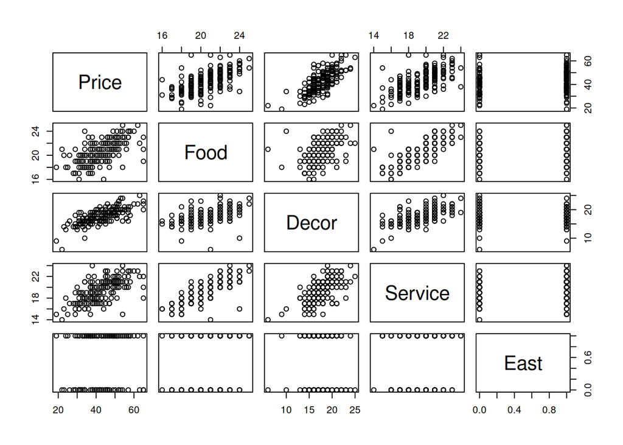

```r
pairs(nyc[vars])
```

1. Which variables have the strongest marginal correlations with `Price`?
2. Which predictors are strongly correlated with one another?

## 2. Fit the full model

```r
mfull <- lm(Price ~ Food + Decor + Service + East, data = nyc)
summary(mfull)
```

```
Call:
lm(formula = Price ~ Food + Decor + Service + East, data = nyc)

Residuals:
    Min      1Q  Median      3Q     Max
-14.046  -3.884   0.037   3.394  17.749

Coefficients:
             Estimate Std. Error t value Pr(>|t|)
(Intercept) -24.02380    4.70836   -5.10  9.2e-07 ***
Food          1.53812    0.36895    4.17  5.0e-05 ***
Decor         1.91009    0.21700    8.80  1.9e-15 ***
Service      -0.00273    0.39623   -0.01     0.99
East          2.06805    0.94674    2.18     0.03 *
---
Signif. codes:  0 '***' 0.001 '**' 0.01 '*' 0.05 '.' 0.1 ' ' 1

Residual standard error: 5.74 on 163 degrees of freedom
Multiple R-squared:  0.628, Adjusted R-squared:  0.619
F-statistic: 68.8 on 4 and 163 DF,  p-value: <2e-16
```

```r
car::vif(mfull)
```

```
   Food   Decor Service    East
   2.71    1.74    3.56    1.06
```

Why can a predictor have a reasonably strong correlation with `Price` but a small or nonsignificant coefficient in the multiple regression model?

## 3. Construct an added-variable plot by hand

To study `Service` after adjusting for `Food`, `Decor`, and `East`:

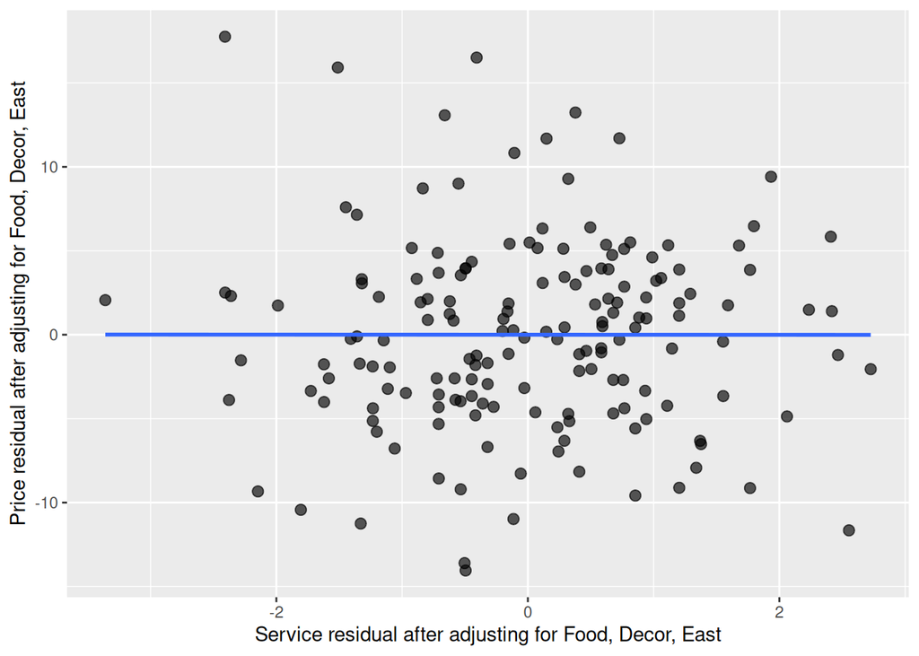

```r
m_y <- lm(Price ~ Food + Decor + East, data = nyc)
m_x <- lm(Service ~ Food + Decor + East, data = nyc)

av_service <- data.frame(
  y_resid = resid(m_y),
  x_resid = resid(m_x)
)

ggplot(av_service, aes(x_resid, y_resid)) +
  geom_point(size = 2.5, alpha = 0.65) +
  geom_smooth(method = "lm", se = FALSE) +
  labs(
    x = "Service residual after adjusting for Food, Decor, East",
    y = "Price residual after adjusting for Food, Decor, East"
  )
```

The slope in this partial regression equals the coefficient of `Service` in the full model.

```r
coef(lm(y_resid ~ x_resid, data = av_service))[2]
```

```
 x_resid
-0.00273
```

```r
coef(mfull)["Service"]
```

```
 Service
-0.00273
```

Explain in words why residualizing both variables isolates the partial relationship between `Service` and `Price`.

## 4. Use `car` for all added-variable plots

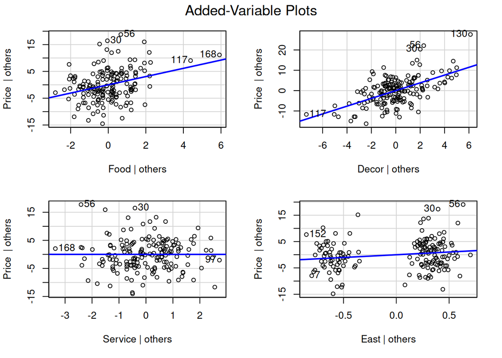

```r
car::avPlots(mfull, id = TRUE)
```

Compare the added-variable plots. Which predictor contributes the clearest additional linear information about price after controlling for the others? Do any observations appear influential?

## 5. Added-variable plots and diagnostics

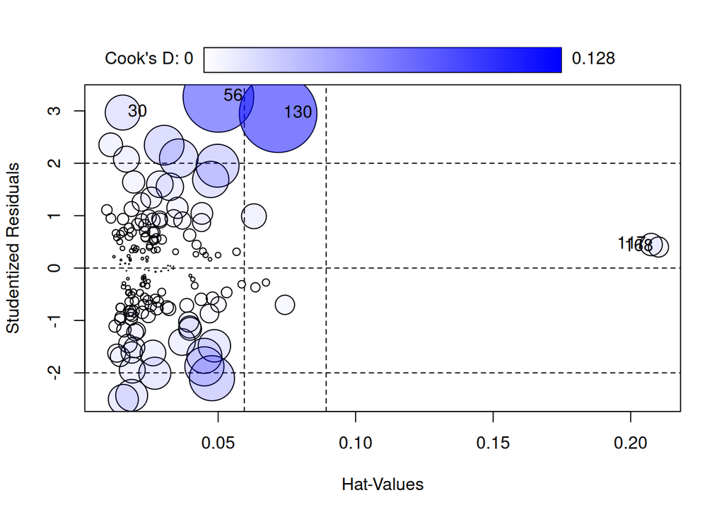

```
    StudRes    Hat   CookD
30    2.968 0.0153 0.02616
56    3.267 0.0501 0.10628
117   0.449 0.2075 0.01062
130   2.946 0.0718 0.12828
168   0.401 0.2101 0.00861
```

```r
car::influencePlot(mfull, id = "noteworthy")
```

An added-variable plot can reveal curvature, unusual cases, or changes in spread associated with one predictor. What do you see here that is less obvious in the ordinary residual-versus-fitted plot?

## Takeaway

A marginal scatterplot asks, “How are (X_j) and (Y) related?” An added-variable plot asks the more relevant multiple-regression question, “How are (X_j) and (Y) related **after the other predictors have been accounted for**?”